# Case Study 2

Hannes Guth, Artem Demidov

2023-04-06

## 1. Orthogonal Factor Analysis

### Check for suitability of the data

```r
# load the necessary packages
library(psych)
library(data.table)
library(knitr)
library(REdaS)
library(corrplot)
library(rcompanion)
library(ggplot2)
```

```r
md = fread("Data File_Case_Study_Factor Analysis_MD.csv")
qds = md[,c(9:41,43:45,51,52,74)] # extract questions, wtps and ris
qds = qds[complete.cases(qds), ] # delete observations with missing values
columns = qds[,34:39] # extract every column that is not refering to a question
qds = qds[,-c(34:39)] # delete those columns
```

**Go through the steps of a factor analysis that you have learned i.e. start with looking at the correlation matrix, check whether the data set and all of its variables are suitable for factor analysis etc. Make appropriate decisions and decide on a final factor solution**

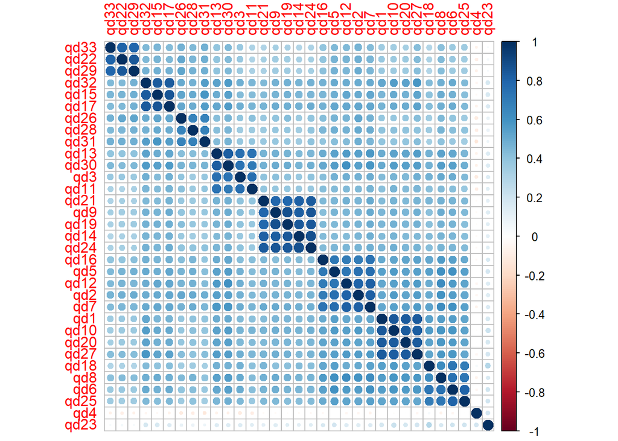

```r
kmo = KMOS(qds) # run the Kaiser-Meyer-Olkin test
corrplot(kmo$cormat, order = "hclust") # plot the correlation matrix
```

This plot gives a first idea which variables could from a factor together, namely those which are in a square in this correlation plot.

The follwwing code will show the *Measure of Sampling Adequacy* of the KMO.

qd4 and qd23 do not seem to be correlated with any other variable. Nevertheless, they will be kept *for some* analyses because they will gain relevance later on in the case study for making up a whole factor alone and contributing high loadings to this factor.

```r
kmo$KMO
```

```
## [1] 0.961722
```

The value is close to 1 and one can therefore assume that the data is very suitable for a factor analysis. Values below 0.6 or 0.5 would indicate that the data were not suitable.

The following code will execute the Barttlet test for sphericity that tests for the equality of variances between/across populations.

```r
bart_spher(qds)
```

```
##  Bartlett's Test of Sphericity
##
## Call: bart_spher(x = qds)
##
##      X2 = 30857.911
##      df = 528
## p-value < 2.22e-16
```

The p-Value is very close to 0, H0 can be rejected. One can assume homoscedasticity.

**Overview about the distribution of answers for all questions/variables** In the following, one will print the histograms of the answers to the questions to see which distribution they approximately follow.

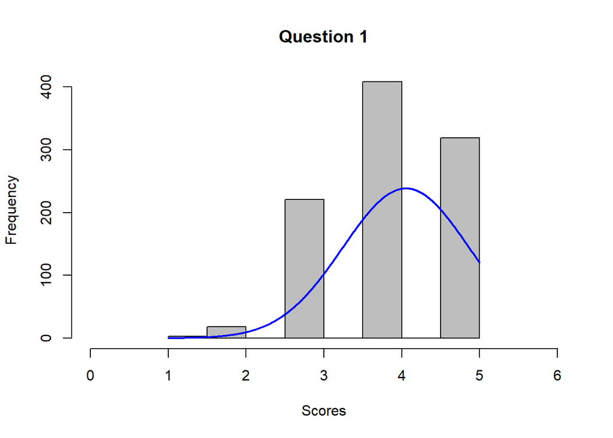

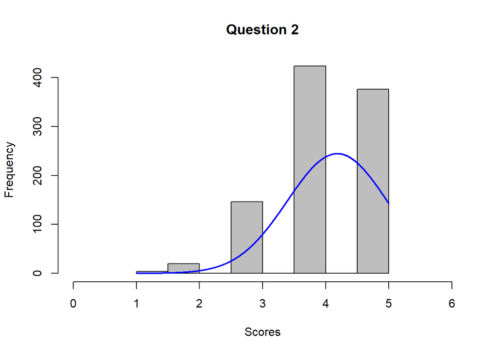

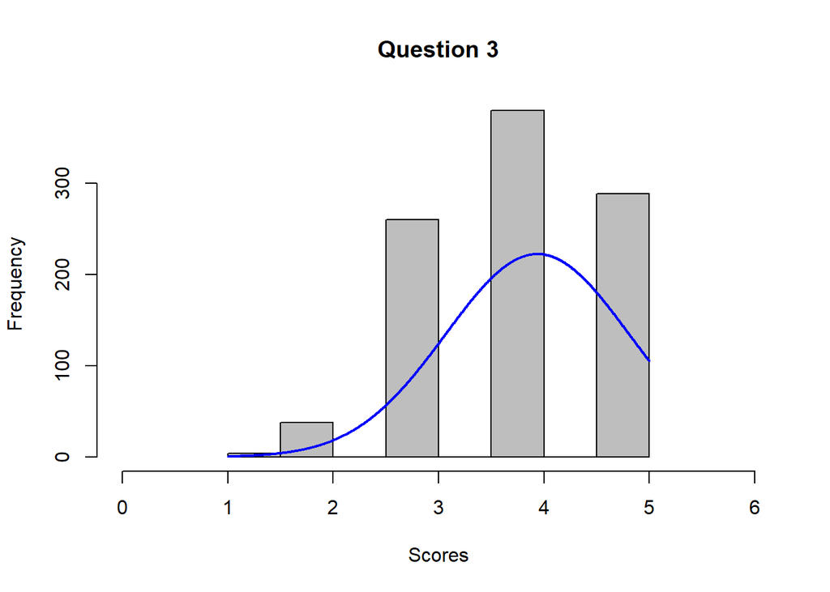

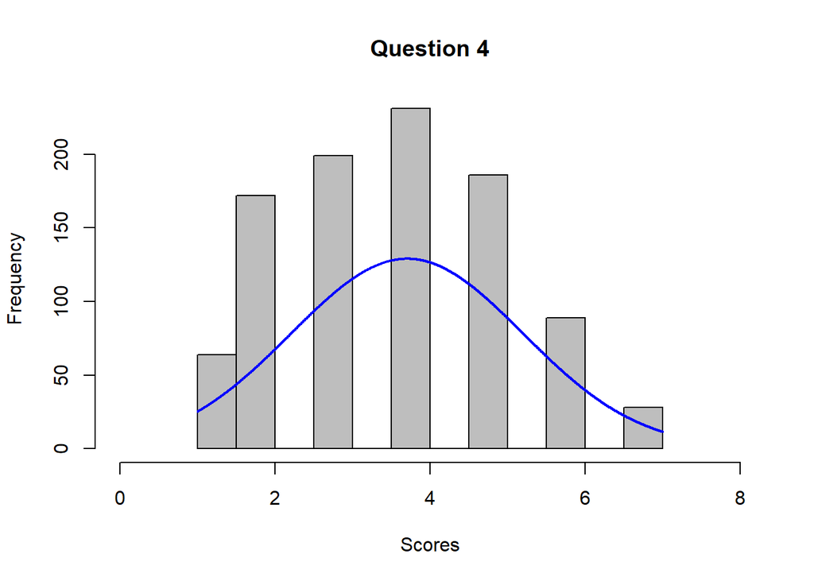

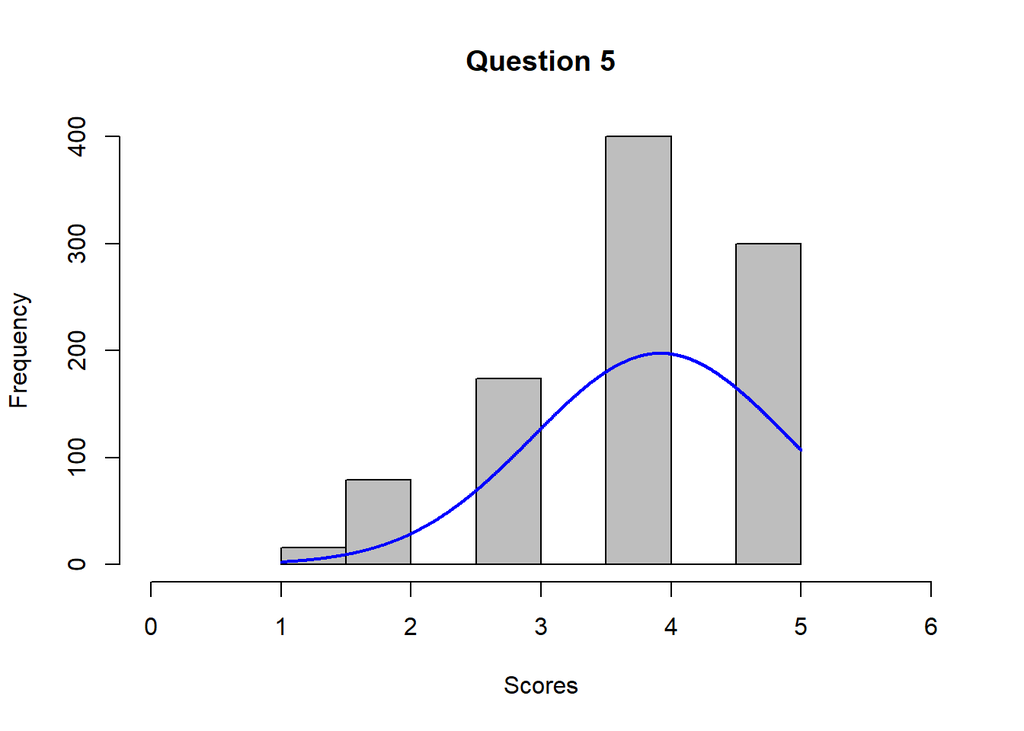

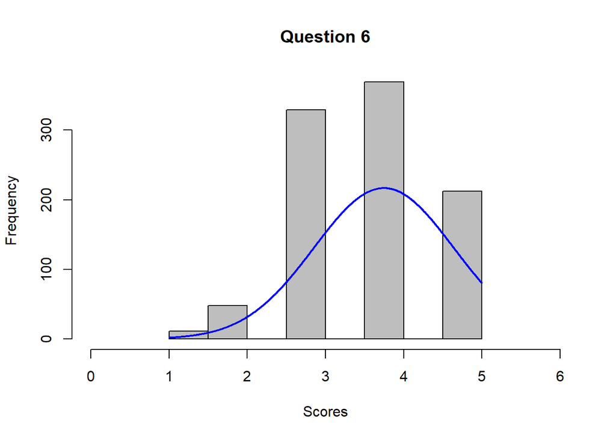

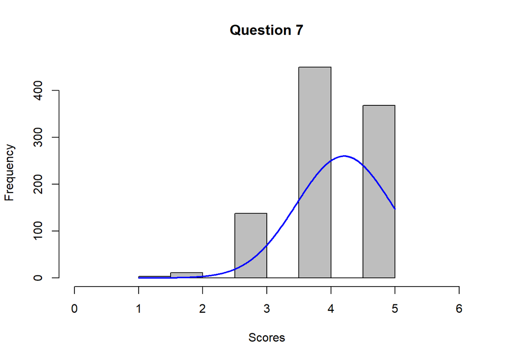

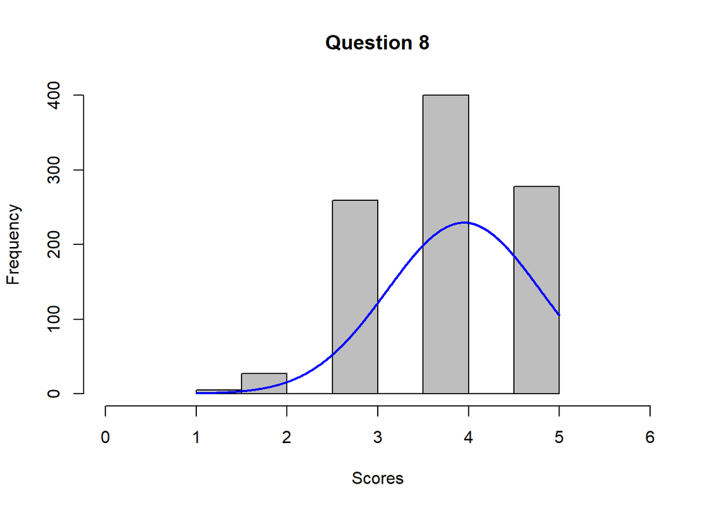

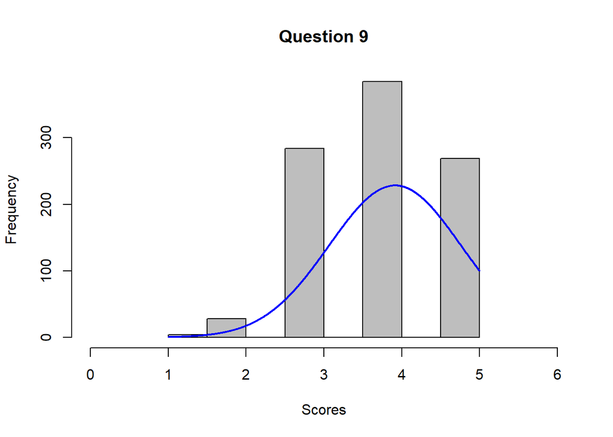

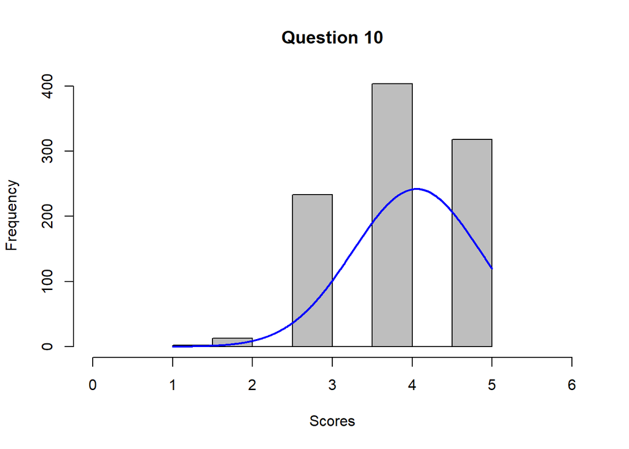

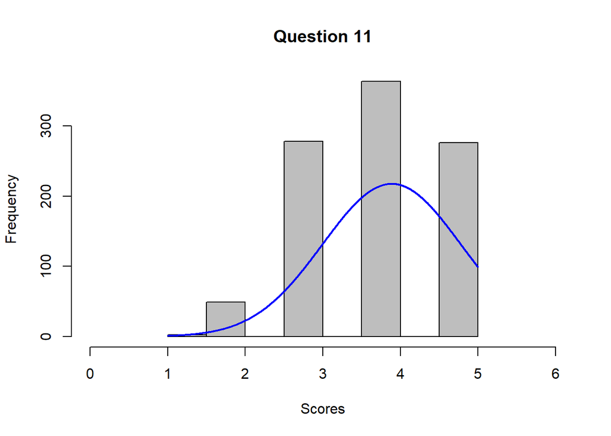

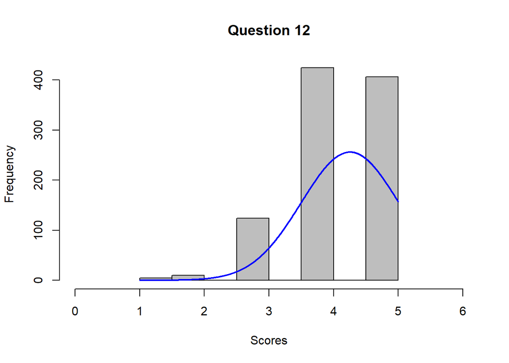

[20 more figures not shown]

```r
for (i in 1:32){
  plotNormalHistogram(qds[,..i],
                      xlab = "Scores",
                      main = paste("Question", i, collapse = ", "),
                      xlim = c(0, max(qds[,..i])+1))
}
```

The graphs reveal that for most questions, the structure of the answers differs. Some are normally distributed, others are strongly skewed in either direction or do not follow any specific distribution.

### Principal Axis Analysis

**Principal Axis Analysis**

**Make appropriate decisions and decide on a final factor solution**

At first, it is necessary to figure out the appropriate number of factors to use. This will be done by evaluating the eigenvalues of factors and only the number of factors that have an eigenvalue > 1 or close to one will be kept. For this, a first model will be created to extract these eigenvalues, then the number of values will be determined graphically.

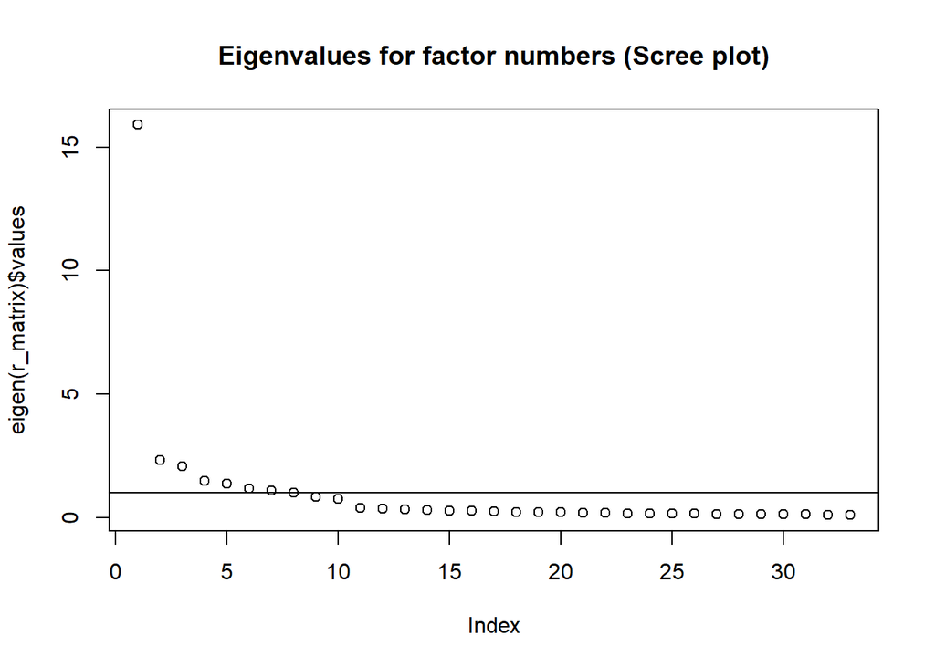

```
## integer(0)
```

```r
r_matrix = corr.test(qds)$r # extracts the correlations between variables
plot(eigen(r_matrix)$values, main = "Eigenvalues for factor numbers (Scree plot)") + abline(h = 1) # plot the Scree plot
```

```r
eigen(r_matrix)$values # show the eigenvalues
```

```
##  [1] 15.9082244  2.3398002  2.0741379  1.4922324  1.3853335  1.1868699
##  [7]  1.0936900  1.0096776  0.8530507  0.7579386  0.4066927  0.3605823
## [13]  0.3509690  0.2970630  0.2858756  0.2773086  0.2574310  0.2361584
## [19]  0.2273536  0.2155112  0.2007128  0.1929568  0.1801325  0.1682817
## [25]  0.1640197  0.1555231  0.1520528  0.1461674  0.1384577  0.1338676
## [31]  0.1288620  0.1156120  0.1074529
```

The are 8 factors with a value above 1, so the first model will be established with 8 factors. The 9th factor below 1 but will still be considered in a second model because it is still “close”, so the 2nd model will take into account 9 factors.

The principal axis factoring model will be established as follows.

```r
af = fa(kmo$cormat, nfactors = 8, rotate = "varimax") # run a principal axis factoring model
```

```r
sort(af$communality) # show the communalities
```

```
##        qd4       qd23       qd16       qd18       qd26       qd28        qd8
## 0.04090199 0.08765688 0.64073594 0.64637489 0.64888598 0.67739749 0.68063045
##       qd31       qd11        qd5       qd33        qd3       qd21       qd30
## 0.70581286 0.71687723 0.72480636 0.76137143 0.76717766 0.77073452 0.77458944
##       qd12       qd25       qd13        qd2        qd6       qd32       qd29
## 0.78207561 0.79296414 0.80247545 0.80527615 0.82805993 0.82910142 0.83095832
##       qd10        qd7       qd20       qd27        qd9       qd19       qd17
## 0.83394608 0.83470317 0.83598899 0.83770007 0.84063162 0.84353647 0.84961939
##       qd14        qd1       qd22       qd15       qd24
## 0.85233462 0.85338996 0.85587510 0.86068426 0.88248762
```

The communality of a variable gives an idea how all factors together explain the variance of the variable. Low values indicate that the variable is not well explained by the factors. Here, qd4 and qd23 have low values and therefore, they will be removed for this approach.

```r
kmo = KMOS(qds[,-c(4,23)]) # delete the columns for qd4 and qd23
af = fa(kmo$cormat, nfactors = 8, rotate = "varimax") # run the model again
sort(af$communality) # show the communalities again
```

```
##      qd18      qd16      qd26       qd8      qd28      qd31      qd11       qd5
## 0.6264756 0.6401977 0.6543623 0.6854270 0.6864510 0.6998168 0.7170257 0.7224507
##      qd33       qd3      qd21      qd30      qd12      qd25       qd2      qd13
## 0.7606924 0.7631400 0.7706616 0.7755797 0.7829022 0.8014884 0.8052686 0.8057144
##      qd32      qd29      qd10       qd7      qd20       qd6      qd27       qd9
## 0.8293067 0.8309835 0.8333236 0.8358204 0.8360452 0.8388622 0.8390417 0.8406222
##      qd19      qd14       qd1      qd15      qd17      qd22      qd24
## 0.8435127 0.8526219 0.8539385 0.8561542 0.8575192 0.8583147 0.8826484
```

One can calculate the eigenvalues for each factor as well as the variance and the part of total variance explained by each factor.

```r
# Total Variance Explained (approach form the course)

# create an empty data table
total_var_explained = data.table("eigenvalue" = numeric(length(qds)-2),
                               "variance" = 0,
                               "total_variance" = 0)

total_var_explained$eigenvalue = af$e.values # get the eigenvalues
total_var_explained$variance = (total_var_explained$eigenvalue / (length(qds)-2)) * 100 # get the variance
total_var_explained$total_variance = cumsum(total_var_explained$eigenvalue / (length(qds)-2)) # get the cumulative variance
kable(head(total_var_explained, 15)) # show the first 15 rows
```

| eigenvalue | variance | total_variance |
| --- | --- | --- |
| 15.8598680 | 51.1608646 | 0.5116086 |
| 2.3217762 | 7.4896008 | 0.5865047 |
| 2.0258331 | 6.5349453 | 0.6518541 |
| 1.4781631 | 4.7682680 | 0.6995368 |
| 1.3712708 | 4.4234540 | 0.7437713 |
| 1.1343846 | 3.6593051 | 0.7803644 |
| 1.0135713 | 3.2695850 | 0.8130602 |
| 0.8689483 | 2.8030591 | 0.8410908 |
| 0.4176516 | 1.3472632 | 0.8545635 |
| 0.3618149 | 1.1671450 | 0.8662349 |
| 0.3511069 | 1.1326029 | 0.8775609 |
| 0.2984164 | 0.9626335 | 0.8871873 |
| 0.2897893 | 0.9348042 | 0.8965353 |
| 0.2773548 | 0.8946931 | 0.9054822 |
| 0.2574651 | 0.8305324 | 0.9137876 |

The following will show the loadings that each question contributes to each factor.

```r
print(af$Structure, cutoff=0.3, sort=TRUE) # show the loadings matrix
```

```
##
## Loadings:
##      MR2   MR1   MR5   MR4   MR3   MR7   MR6   MR8
## qd9  0.827
## qd14 0.851
## qd19 0.832
## qd21 0.785
## qd24 0.860
## qd2        0.723
## qd5        0.645
## qd7        0.738
## qd12       0.711
## qd16       0.616
## qd1              0.797
## qd10             0.749
## qd20             0.772
## qd27             0.747
## qd3                    0.759
## qd11                   0.749
## qd13                   0.739
## qd30                   0.677
## qd22                         0.838
## qd29                         0.813
## qd33                         0.779
## qd6                                0.741
## qd8        0.341                   0.558
## qd18                               0.601
## qd25                               0.763
## qd15                                     0.750
## qd17                                     0.744
## qd32                                     0.715
## qd26                                           0.619
## qd28                                           0.673
## qd31                                           0.660
##
##                  MR2   MR1   MR5   MR4   MR3   MR7   MR6   MR8
## SS loadings    4.569 3.577 3.404 3.121 2.781 2.675 2.324 1.935
## Proportion Var 0.147 0.115 0.110 0.101 0.090 0.086 0.075 0.062
## Cumulative Var 0.147 0.263 0.373 0.473 0.563 0.649 0.724 0.787
```

The loadings matrix looks acceptable. Only 1 observation (qd8 for MR1) shows a medium loading value. Nevertheless, the loadings are not too high, no loading reaches 0.9 and only few exceed 0.8. A considerable amount has values between 0.6 and 0.8. 78.7 % of the variance could be explained.  
Since an additional factor (in addition to the 8) has a value “close” to 1, it will be considered in the following, what might improve the result.

```r
af9 = fa(kmo$cormat, nfactors = 9, rotate = "varimax") # run the axis factoring model with 9 factors
```

```r
print(af9$Structure, cutoff = 0.3, sort = TRUE) # show the loadings matrix
```

```
##
## Loadings:
##      MR2    MR1    MR5    MR4    MR3    MR7    MR6    MR8    MR9
## qd9   0.829
## qd14  0.851
## qd19  0.833
## qd21  0.786
## qd24  0.860
## qd2          0.722
## qd5          0.648
## qd7          0.736
## qd12         0.715
## qd16         0.620
## qd1                 0.799
## qd10                0.751
## qd20                0.775
## qd27                0.748
## qd3                        0.756
## qd11                       0.758
## qd13                       0.733
## qd30                       0.679
## qd22                              0.839
## qd29                              0.814
## qd33                              0.780
## qd6                                      0.736
## qd8          0.340                       0.561
## qd18                                     0.611
## qd25                                     0.759
## qd15                                            0.751
## qd17                                            0.746
## qd32                                            0.715
## qd26                                                   0.619
## qd28                                                   0.676
## qd31                                                   0.659
##
##                  MR2   MR1   MR5   MR4   MR3   MR7   MR6   MR8   MR9
## SS loadings    4.585 3.586 3.436 3.078 2.792 2.659 2.340 1.946 0.151
## Proportion Var 0.148 0.116 0.111 0.099 0.090 0.086 0.075 0.063 0.005
## Cumulative Var 0.148 0.264 0.374 0.474 0.564 0.650 0.725 0.788 0.793
```

**Interpret the factors based on the literature review on quality dimensions (see table 1).**

**Serviceability** - MR2  
9. the competence of my smartphone’s customer service staff is  
14. the promptness with which my smartphone’s customer service reacts to my issues is  
19. the level of professionalism shown by the service staff is  
21. the accessibility of my smartphone’s customer service is  
24. the responsiveness of my smartphone’s customer service staff is

**Performance** - MR1  
2. my smartphone consistently performs  
5. the performance of my smartphone is excellent  
7. the overall performance of my smartphone is  
12. how well does your smartphone performs its core functions  
16. the functioning speed of my smartphone (i.e. time taken to turn ON/OFF, open apps, multi-task etc) is

**Features/Versatility** - MR7  
6. the innovativeness of the extra features offered by my smartphone is  
8. the extra features offered in my smartphone usually function  
18. the excitement I get from my smartphone’s extra features is  
25. the number of additional features my smartphone offers is

**Ease of use** - MR4  
3. my user experience with the various functions my smartphone offers is/was  
11. my experience to learn how to properly operate my smartphone with all its functionalities is/was  
13. my smartphone’s ease of use is  
30. the usability of my smartphone is

**Reliability/Flawlessness** - MR3  
22. the severity of defects/glitches of my smartphone is  
29. the frequency of defects/glitches of my smartphone is  
33. my smartphone’s probability of failure or malfunctioning

**Durability** - MR8  
26. the time span for which my smartphone runs without any major defects is  
28. the amount of time for which my smartphone works perfectly even under heavy usage (ex. everyday usage) is  
31. the life span of my smartphone is

**Do all of the variables in your final solution show clear loading patterns?**  
This analysis is conducted according to the findings of Thurstone, 1947.

At first, it will be checked if there are values for each variable that are close to 0. An appropriate cutoff value seems to be 0.15, so in the following, only values larger than 0.15 will be shown and the gaps will stand for close to zero values.

```r
print(af$Structure, cutoff = 0.15, sort = TRUE) # show the loadings matrix with a changed cutoff value to get an overview about the close to zero values
```

```
##
## Loadings:
##      MR2   MR1   MR5   MR4   MR3   MR7   MR6   MR8
## qd9  0.827 0.160 0.170 0.167       0.158
## qd14 0.851 0.165                   0.153
## qd19 0.832 0.170 0.168 0.158
## qd21 0.785 0.189 0.158 0.175       0.170
## qd24 0.860 0.161 0.171
## qd2  0.212 0.723 0.216 0.197 0.220 0.189       0.216
## qd5  0.203 0.645 0.236 0.205 0.208 0.278       0.157
## qd7  0.252 0.738 0.199 0.230 0.172 0.237       0.166
## qd12 0.211 0.711 0.221 0.237 0.200 0.212 0.155
## qd16 0.209 0.616 0.240 0.186 0.155 0.242       0.151
## qd1  0.210 0.207 0.797 0.168       0.228
## qd10 0.233 0.242 0.749 0.217       0.243 0.172
## qd20 0.213 0.226 0.772 0.204       0.226 0.156
## qd27 0.217 0.238 0.747 0.219 0.194 0.199 0.204
## qd3  0.177 0.171 0.164 0.759 0.152 0.218
## qd11 0.173 0.169 0.169 0.749                   0.164
## qd13 0.224 0.259 0.224 0.739 0.154 0.162 0.161
## qd30 0.245 0.260 0.224 0.677 0.196 0.185 0.208 0.153
## qd22       0.191             0.838             0.190
## qd29       0.196             0.813       0.169 0.197
## qd33       0.178       0.158 0.779             0.185
## qd6  0.221 0.278 0.257 0.211       0.741 0.162
## qd8  0.239 0.341 0.263 0.228 0.188 0.558       0.159
## qd18 0.215 0.254 0.282 0.221       0.601
## qd25 0.212 0.233 0.226 0.160       0.763
## qd15 0.225 0.200 0.187 0.190 0.217       0.750 0.252
## qd17 0.254 0.205 0.186 0.231 0.189 0.166 0.744 0.215
## qd32 0.228 0.172 0.269 0.235 0.200 0.163 0.715 0.206
## qd26 0.191 0.216       0.189 0.294       0.196 0.619
## qd28 0.167 0.245             0.222 0.168 0.160 0.673
## qd31 0.176 0.158       0.181 0.257       0.283 0.660
##
##                  MR2   MR1   MR5   MR4   MR3   MR7   MR6   MR8
## SS loadings    4.569 3.577 3.404 3.121 2.781 2.675 2.324 1.935
## Proportion Var 0.147 0.115 0.110 0.101 0.090 0.086 0.075 0.062
## Cumulative Var 0.147 0.263 0.373 0.473 0.563 0.649 0.724 0.787
```

### Principal Component Analysis

**Principal Component Analysis**

**Are there differences to your solution based on principal axis factoring?**

As for the principal axis factoring, the first thing to be found out is the appropriate number of factors. The same approach will be followed.

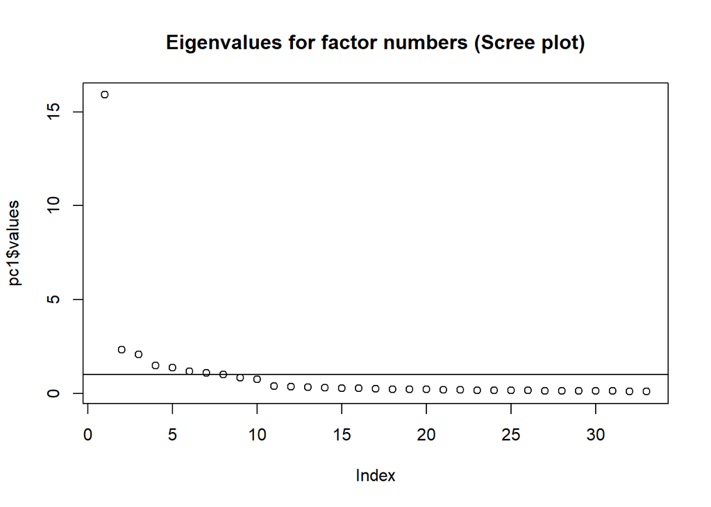

```
## integer(0)
```

```r
pc1 = principal(qds, rotate = "varimax", scores = TRUE) # run a first principal component analysis
plot(pc1$values, main = "Eigenvalues for factor numbers (Scree plot)") + abline(h=1) # show the scree plot
```

```r
pc1$values # show the eigenvalues
```

```
##  [1] 15.9082244  2.3398002  2.0741379  1.4922324  1.3853335  1.1868699
##  [7]  1.0936900  1.0096776  0.8530507  0.7579386  0.4066927  0.3605823
## [13]  0.3509690  0.2970630  0.2858756  0.2773086  0.2574310  0.2361584
## [19]  0.2273536  0.2155112  0.2007128  0.1929568  0.1801325  0.1682817
## [25]  0.1640197  0.1555231  0.1520528  0.1461674  0.1384577  0.1338676
## [31]  0.1288620  0.1156120  0.1074529
```

8 values have an eigenvalue larger than 1, so the first try will include 8 factors.

```r
pc = principal(qds, rotate = "varimax", nfactors = 8, scores = TRUE) # run a principal component analysis with 8 factors
```

Now, the explained total variance will be extracted from the model and then examined.

```r
# Total Variance Explained (approach from the course)

# create an empty data table
total_var_explained = data.table("eigenvalue" = numeric(length(qds)),
                               "variance" = 0,
                               "total_variance" = 0)

total_var_explained$eigenvalue = pc$values # get the eigenvalues
total_var_explained$variance = (total_var_explained$eigenvalue / length(qds)) * 100 # get the variance
total_var_explained$total_variance = cumsum(total_var_explained$eigenvalue / length(qds)) # get the accumulated variance
kable(head(total_var_explained, 15)) # show the first 15 rows
```

| eigenvalue | variance | total_variance |
| --- | --- | --- |
| 15.9082244 | 48.2067407 | 0.4820674 |
| 2.3398002 | 7.0903037 | 0.5529704 |
| 2.0741379 | 6.2852665 | 0.6158231 |
| 1.4922324 | 4.5219164 | 0.6610423 |
| 1.3853335 | 4.1979804 | 0.7030221 |
| 1.1868699 | 3.5965755 | 0.7389878 |
| 1.0936900 | 3.3142121 | 0.7721300 |
| 1.0096776 | 3.0596291 | 0.8027262 |
| 0.8530507 | 2.5850023 | 0.8285763 |
| 0.7579386 | 2.2967837 | 0.8515441 |
| 0.4066927 | 1.2324022 | 0.8638681 |
| 0.3605823 | 1.0926736 | 0.8747949 |
| 0.3509690 | 1.0635424 | 0.8854303 |
| 0.2970630 | 0.9001911 | 0.8944322 |
| 0.2858756 | 0.8662897 | 0.9030951 |

The first 8 factors, those with an eigenvalue > 1, explain 80.27% of the total variance. It is remarkable that the 1st factor has an eigenvalue of over 15.

The loading matrix looks as follows.

```r
print(pc$loadings, cutoff=0.3, sort=TRUE) # show the loadings matrix with a cutoff of 0.3
```

```
##
## Loadings:
##      RC2    RC1    RC7    RC5    RC4    RC8    RC3    RC6
## qd9   0.847
## qd14  0.868
## qd19  0.851
## qd21  0.823
## qd24  0.868
## qd2          0.758
## qd5          0.700
## qd7          0.755
## qd12         0.742
## qd16         0.703
## qd15                0.768
## qd17                0.740
## qd26                0.597                       0.322
## qd28         0.339  0.590
## qd31                0.692
## qd32                0.720  0.309
## qd1                        0.816
## qd10                       0.776
## qd20                       0.801
## qd27                       0.778
## qd3                               0.806
## qd11                              0.812
## qd13                              0.760
## qd30                              0.706
## qd6                                      0.752
## qd8          0.349                       0.620
## qd18                                     0.700
## qd25                                     0.791
## qd22                                            0.849
## qd29                                            0.836
## qd33                                            0.838
## qd4                                                    0.805
## qd23                                                   0.677
##
##                  RC2   RC1   RC7   RC5   RC4   RC8   RC3   RC6
## SS loadings    4.682 3.973 3.931 3.544 3.306 2.952 2.862 1.240
## Proportion Var 0.142 0.120 0.119 0.107 0.100 0.089 0.087 0.038
## Cumulative Var 0.142 0.262 0.381 0.489 0.589 0.678 0.765 0.803
```

The structure does not look as clear as for the principal axis factoring because more medium sized loadings appear but one could explain 80.3% of the variance what is a higher value than for the PAF approach.

Nevertheless, since the eigenvalue of the 9th factor is still “close” to 1, this model will be established as follows. If the 9th factor has a clear interpretation and good loadings, this may be reasonable.

```r
pc = principal(qds, rotate = "varimax", nfactors = 9, scores = TRUE) # run a principal component analysis with 9 factors
sort(pc$communality) # show the communalities
```

```
##      qd23       qd4      qd16       qd8      qd18      qd26       qd5      qd31
## 0.6111628 0.6944232 0.7264567 0.7481733 0.7506566 0.7686232 0.7796323 0.7856484
##      qd28      qd30      qd11      qd12      qd21       qd3       qd2      qd13
## 0.7912779 0.8130517 0.8163051 0.8224636 0.8254810 0.8325032 0.8356990 0.8388698
##      qd25       qd7      qd33       qd6       qd9      qd10      qd19      qd27
## 0.8405030 0.8535114 0.8555067 0.8555993 0.8713694 0.8727460 0.8741072 0.8758353
##      qd29      qd20      qd14      qd22      qd32       qd1      qd24      qd17
## 0.8777684 0.8798647 0.8806417 0.8858066 0.8879444 0.8909582 0.8976776 0.9010272
##      qd15
## 0.9017220
```

There are no low communalities observable, so every variable will be kept. qd4 and qd23 still have the lowest values but they are even higher than 0.6.

```r
print(pc$loadings, cutoff = 0.3, sort = TRUE) # show the loadings matrix with the cutoff 0.3
```

```
##
## Loadings:
##      RC2    RC1    RC5    RC4    RC8    RC3    RC7    RC9    RC6
## qd9   0.848
## qd14  0.869
## qd19  0.852
## qd21  0.825
## qd24  0.870
## qd2          0.757
## qd5          0.706
## qd7          0.760
## qd12         0.752
## qd16         0.708
## qd1                 0.823
## qd10                0.778
## qd20                0.804
## qd27                0.774
## qd3                        0.807
## qd11                       0.819
## qd13                       0.761
## qd30                       0.705
## qd6                               0.754
## qd8          0.351                0.621
## qd18                              0.699
## qd25                              0.792
## qd22                                     0.849
## qd29                                     0.839
## qd33                                     0.841
## qd15                                            0.786
## qd17                                            0.780
## qd32                                            0.764
## qd26                                                   0.723
## qd28                                                   0.759
## qd31                                                   0.728
## qd4                                                           0.803
## qd23                                                          0.717
##
##                  RC2   RC1   RC5   RC4   RC8   RC3   RC7   RC9   RC6
## SS loadings    4.720 3.978 3.514 3.313 2.953 2.855 2.488 2.310 1.211
## Proportion Var 0.143 0.121 0.106 0.100 0.089 0.087 0.075 0.070 0.037
## Cumulative Var 0.143 0.264 0.370 0.470 0.560 0.646 0.722 0.792 0.829
```

The pattern of the loadings matrix was enhanced. As could have already been observed in the analysis of the total variance explained, now 82.9% could have been explained table, compared to 80.2% for the model with 8 factors. It does not seem appropriate to exclude any further variables. Choosing 9 factors appears to be the best choice.

The factors can be interpreted in the following way. Most of them are the same as for the principal axis factoring, therefore, the columns will just be renamed. The only new factor that is introduced by including 9 factors is *Distinctiveness/Prestige*. The previously explicitly kept variables qd4 and qd23 alone make up this factor and contribute high loading of 0.803 and 0.717 respectively. For reasons of clearness, abbreviations will be used for the factors.

```r
colnames(pc$Structure) = c("Serv", "Perf", "Ae/App", "EOU", "Feat/Vers", "Dur", "Con", "Rel/Flawl", "Dist/Pr") #  rename the columns with the respective abbreviations
```

In the following, the loading patterns will be examined as above for the principal axis analysis, setting the same cutoff value of 0.15.

```r
print(pc$Structure, cutoff = 0.15, sort = TRUE) # show the loadings matrix with the cutoff 0.15
```

```
##
## Loadings:
##      Serv   Perf   Ae/App EOU    Feat/Vers Dur    Con    Rel/Flawl Dist/Pr
## qd9   0.848  0.163  0.167  0.162  0.156
## qd14  0.869  0.168                0.152
## qd19  0.852  0.174  0.165  0.152
## qd21  0.825  0.192  0.151  0.167  0.166
## qd24  0.870  0.166  0.169
## qd2   0.209  0.757  0.208  0.188  0.178     0.207         0.215
## qd5   0.195  0.706  0.221  0.193  0.264     0.197         0.152
## qd7   0.250  0.760  0.189  0.223  0.234     0.156         0.166
## qd12  0.206  0.752  0.211  0.229  0.202     0.185  0.155
## qd16  0.200  0.708  0.226  0.167  0.221
## qd1   0.208  0.213  0.823  0.161  0.222
## qd10  0.229  0.245  0.778  0.211  0.241            0.168
## qd20  0.210  0.233  0.804  0.195  0.217            0.153
## qd27  0.213  0.241  0.774  0.213  0.198     0.185  0.204
## qd3   0.173  0.169  0.154  0.807  0.226
## qd11  0.168  0.168  0.163  0.819                          0.167
## qd13  0.224  0.271  0.224  0.761  0.153     0.151  0.161
## qd30  0.244  0.272  0.222  0.705  0.175     0.193  0.213
## qd6   0.220  0.288  0.251  0.200  0.754            0.168
## qd8   0.236  0.351  0.252  0.211  0.621     0.186
## qd18  0.206  0.235  0.260  0.214  0.699                             0.165
## qd25  0.212  0.240  0.216         0.792
## qd22         0.195                          0.849         0.202
## qd29         0.203                          0.839  0.170  0.201
## qd33         0.179         0.154            0.841         0.178
## qd15  0.222  0.208  0.180  0.181            0.207  0.786  0.245
## qd17  0.253  0.215  0.180  0.222  0.164     0.176  0.780  0.208
## qd32  0.224  0.179  0.266  0.226  0.159     0.189  0.764  0.197
## qd26  0.190  0.215         0.182            0.275  0.174  0.723
## qd28  0.164  0.257                0.162     0.196         0.759
## qd31  0.174  0.154  0.153  0.170            0.235  0.293  0.728
## qd4                                                      -0.159     0.803
## qd23                              0.225                             0.717
##
##                 Serv  Perf Ae/App   EOU Feat/Vers   Dur   Con Rel/Flawl Dist/Pr
## SS loadings    4.720 3.978  3.514 3.313     2.953 2.855 2.488     2.310   1.211
## Proportion Var 0.143 0.121  0.106 0.100     0.089 0.087 0.075     0.070   0.037
## Cumulative Var 0.143 0.264  0.370 0.470     0.560 0.646 0.722     0.792   0.829
```

There is not a single row that has not at least one near zero value, using the threshold 0.15. Unfortunately, the factors have partly very low numbers of near zero values, like *Performance* that has only 2.  
Nevertheless, this approach is considered a bit stronger because it explains more of the variance and does not have any severe disadvantages.

**What do the eigenvalues of the factors/quality dimensions tell us about their relevance for repurchase behavior?**

The eigenvalue of a factor defines how much this factor contributes to explain the total variance of repurchase behavior and is the sum of the squared loadings that go into one factor. The larger the eigenvalue of a factor is, the larger is its impact on repurchase behavior without making any statement about the direction of influence.

## 2. Oblique Factor Analysis

### Computational part

In 1. there were no variables excluded because using the principal component analysis delivered results that justified keeping all variables. Therefore, the whole set will be used in this part as well.

**Run an oblique factor analysis with the variables of your final solution in exercise 1 using Promax.**

```r
pc_pro = principal(qds, rotate = "promax", nfactors = 9, scores = TRUE) # run a principal component analysis with promax
colnames(pc_pro$loadings) = c("Serv", "Perf", "Ae/App", "EOU", "Feat/Vers", "Dur", "Con", "Rel/Flawl", "Dist/Pr") # rename the columns respectively
print(round(pc_pro$loadings,4), cutoff = 0.3, sort = TRUE) # print the loadings matrix with the cutoff 0.3
```

```
##
## Loadings:
##      Serv   Perf   Ae/App EOU    Feat/Vers Dur    Con    Rel/Flawl Dist/Pr
## qd9   0.917
## qd14  0.953
## qd19  0.924
## qd21  0.891
## qd24  0.948
## qd2          0.910
## qd5          0.815
## qd7          0.908
## qd12         0.905
## qd16         0.850
## qd1                 0.978
## qd10                0.886
## qd20                0.939
## qd27                0.885
## qd3                        0.950
## qd11                       0.983
## qd13                       0.860
## qd30                       0.762
## qd6                               0.893
## qd8                               0.682
## qd18                              0.817
## qd25                              0.979
## qd15                                        0.942
## qd17                                        0.936
## qd32                                        0.907
## qd22                                               0.927
## qd29                                               0.909
## qd33                                               0.925
## qd26                                                      0.829
## qd28                                                      0.898
## qd31                                                      0.824
## qd4                                                                 0.823
## qd23                                                                0.705
##
##                 Serv  Perf Ae/App   EOU Feat/Vers   Dur   Con Rel/Flawl Dist/Pr
## SS loadings    4.309 3.944  3.437 3.229     3.018 2.637 2.611     2.261   1.204
## Proportion Var 0.131 0.120  0.104 0.098     0.091 0.080 0.079     0.069   0.036
## Cumulative Var 0.131 0.250  0.354 0.452     0.544 0.623 0.703     0.771   0.808
```

**How high are the factors correlated and what is the highest correlation between factors. What does this mean – please explain.**

**The following table shows the correlation between the factors.**

```r
# rename columns and rows for the correlations and weights tables in pc_pro
colnames(pc_pro$r.scores) = c("Serv", "Perf", "Ae/App", "EOU", "Feat/Vers", "Dur", "Con", "Rel/Flawl", "Dist/Pr")
rownames(pc_pro$r.scores) = c("Serv", "Perf", "Ae/App", "EOU", "Feat/Vers", "Dur", "Con", "Rel/Flawl", "Dist/Pr")
colnames(pc_pro$weights) = c("Serv", "Perf", "Ae/App", "EOU", "Feat/Vers", "Dur", "Con", "Rel/Flawl", "Dist/Pr")
kable(round(pc_pro$r.scores,2)) # show the correlations
```

|  | Serv | Perf | Ae/App | EOU | Feat/Vers | Dur | Con | Rel/Flawl | Dist/Pr |
| --- | --- | --- | --- | --- | --- | --- | --- | --- | --- |
| Serv | 1.00 | 0.54 | 0.52 | 0.50 | 0.52 | 0.52 | 0.37 | 0.45 | 0.05 |
| Perf | 0.54 | 1.00 | 0.63 | 0.61 | 0.67 | 0.57 | 0.53 | 0.57 | 0.06 |
| Ae/App | 0.52 | 0.63 | 1.00 | 0.57 | 0.64 | 0.56 | 0.42 | 0.47 | 0.11 |
| EOU | 0.50 | 0.61 | 0.57 | 1.00 | 0.58 | 0.57 | 0.43 | 0.51 | 0.03 |
| Feat/Vers | 0.52 | 0.67 | 0.64 | 0.58 | 1.00 | 0.52 | 0.39 | 0.48 | 0.14 |
| Dur | 0.52 | 0.57 | 0.56 | 0.57 | 0.52 | 1.00 | 0.50 | 0.61 | 0.06 |
| Con | 0.37 | 0.53 | 0.42 | 0.43 | 0.39 | 0.50 | 1.00 | 0.55 | -0.06 |
| Rel/Flawl | 0.45 | 0.57 | 0.47 | 0.51 | 0.48 | 0.61 | 0.55 | 1.00 | -0.01 |
| Dist/Pr | 0.05 | 0.06 | 0.11 | 0.03 | 0.14 | 0.06 | -0.06 | -0.01 | 1.00 |

It is reasonable to use oblique rotation when the correlations between factors are higher than 0.3, what is here the case, regarding the table above.

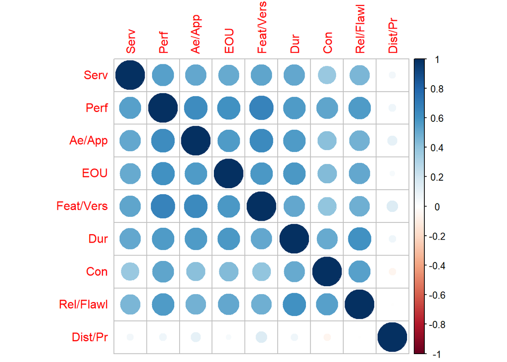

```r
options(scipen=999) # avoid scientific notation
corrplot(pc_pro$r.scores) # show the correlation plot
```

```r
kable(round(pc_pro$weights,2)) # show the weights table
```

|  | Serv | Perf | Ae/App | EOU | Feat/Vers | Dur | Con | Rel/Flawl | Dist/Pr |
| --- | --- | --- | --- | --- | --- | --- | --- | --- | --- |
| qd1 | 0.00 | -0.01 | 0.28 | -0.01 | 0.00 | -0.02 | 0.00 | 0.01 | 0.00 |
| qd2 | 0.00 | 0.23 | 0.00 | -0.01 | -0.03 | -0.01 | 0.01 | 0.03 | -0.01 |
| qd3 | -0.01 | -0.02 | -0.01 | 0.29 | 0.03 | -0.01 | 0.01 | -0.02 | -0.01 |
| qd4 | 0.01 | 0.02 | 0.01 | -0.02 | -0.06 | 0.00 | 0.04 | -0.06 | 0.68 |
| qd5 | -0.01 | 0.21 | 0.00 | -0.01 | 0.02 | 0.00 | 0.01 | -0.01 | 0.04 |
| qd6 | 0.00 | 0.00 | 0.00 | 0.00 | 0.30 | 0.02 | -0.01 | -0.01 | -0.03 |
| qd7 | 0.01 | 0.23 | -0.01 | 0.00 | 0.00 | 0.00 | -0.01 | 0.00 | -0.02 |
| qd8 | 0.00 | 0.03 | 0.01 | 0.00 | 0.22 | -0.01 | 0.02 | 0.01 | -0.06 |
| qd9 | 0.21 | -0.01 | 0.00 | 0.00 | 0.00 | 0.00 | 0.01 | 0.00 | 0.00 |
| qd10 | 0.00 | 0.00 | 0.26 | 0.01 | 0.01 | 0.00 | -0.02 | 0.00 | 0.01 |
| qd11 | 0.00 | -0.01 | 0.00 | 0.30 | -0.02 | -0.01 | -0.03 | 0.03 | 0.00 |
| qd12 | 0.00 | 0.23 | 0.00 | 0.01 | -0.01 | 0.01 | 0.00 | -0.02 | -0.01 |
| qd13 | 0.01 | 0.02 | 0.01 | 0.27 | -0.02 | 0.00 | 0.01 | -0.01 | 0.01 |
| qd14 | 0.22 | 0.00 | -0.01 | -0.01 | 0.00 | 0.01 | 0.00 | -0.02 | -0.01 |
| qd15 | 0.00 | 0.00 | -0.01 | -0.01 | 0.00 | 0.36 | 0.00 | 0.01 | 0.01 |
| qd16 | 0.00 | 0.22 | 0.01 | -0.01 | 0.00 | 0.00 | -0.02 | 0.00 | 0.01 |
| qd17 | 0.01 | 0.01 | -0.01 | 0.00 | 0.00 | 0.35 | -0.01 | -0.01 | -0.02 |
| qd18 | 0.00 | -0.01 | 0.01 | 0.02 | 0.27 | -0.02 | -0.02 | 0.01 | 0.10 |
| qd19 | 0.21 | 0.00 | 0.00 | 0.00 | -0.01 | 0.00 | 0.01 | 0.01 | 0.01 |
| qd20 | 0.00 | 0.00 | 0.27 | 0.00 | 0.00 | 0.00 | -0.01 | 0.00 | 0.00 |
| qd21 | 0.21 | 0.01 | -0.01 | 0.01 | 0.01 | -0.02 | 0.00 | 0.00 | -0.01 |
| qd22 | 0.00 | 0.00 | 0.00 | -0.01 | 0.00 | -0.01 | 0.36 | 0.00 | 0.00 |
| qd23 | -0.01 | -0.03 | -0.01 | 0.04 | 0.09 | 0.00 | -0.06 | 0.10 | 0.60 |
| qd24 | 0.22 | 0.00 | 0.00 | 0.00 | -0.01 | 0.00 | -0.01 | 0.02 | 0.00 |
| qd25 | 0.00 | -0.01 | -0.01 | -0.02 | 0.32 | 0.00 | 0.01 | 0.00 | -0.01 |
| qd26 | 0.01 | 0.00 | -0.01 | 0.01 | -0.01 | -0.02 | 0.02 | 0.37 | 0.01 |
| qd27 | 0.00 | 0.00 | 0.26 | 0.01 | -0.01 | 0.02 | 0.03 | -0.02 | -0.01 |
| qd28 | 0.00 | 0.02 | 0.00 | -0.01 | 0.02 | -0.04 | -0.02 | 0.40 | 0.00 |
| qd29 | 0.00 | 0.00 | 0.00 | 0.00 | -0.01 | 0.01 | 0.35 | 0.00 | 0.00 |
| qd30 | 0.01 | 0.02 | 0.01 | 0.24 | -0.01 | 0.03 | 0.02 | -0.01 | 0.00 |
| qd31 | 0.00 | -0.02 | 0.01 | 0.00 | -0.02 | 0.05 | 0.00 | 0.36 | -0.02 |
| qd32 | 0.00 | -0.01 | 0.03 | 0.01 | 0.00 | 0.34 | 0.00 | -0.01 | 0.00 |
| qd33 | 0.00 | -0.01 | 0.00 | 0.01 | 0.01 | 0.00 | 0.35 | -0.01 | 0.00 |

**Compute factor scores for your factors and name and label them appropriately.**

```r
qds = cbind(qds, columns, pc_pro$scores) # re-unite qds with the previously extracted wtp and ri elements
colnames(qds)[40:48] = c("Serviceability", "Performance", "Aesthetics_Appearance", "Ease_of_use", "Features_Versatility", "Durability", "Conformance", "Reliability_Flawlessness", "Distinctiveness_Prestige") # assign the column names
```

**Compute mean scores for the three willingness to pay premium items (wtp1-wtp3) and the two repurchase intention items (ri1-ri2).**

```r
qds$mean_wtp = (qds$wtp1 + qds$wtp2 + qds$wtp3)/3 # calculate the mean for the willingnesses to pay
qds$mean_ri = (qds$ri1 + qds$ri2)/2 # calculate the mean for the repurchase intentions
```

**Run a regression analysis with the factor scores of the quality dimensions as independent and both the mean score of willingness to pay premium and repurchase intention as dependent variables.**

```r
model_wtp = lm(mean_wtp ~ Serviceability + Performance + Aesthetics_Appearance + Ease_of_use + Features_Versatility + Durability + Conformance + Reliability_Flawlessness + Distinctiveness_Prestige, qds) # create a linear model for the wtp

summary(model_wtp) # show the model summary
```

```
##
## Call:
## lm(formula = mean_wtp ~ Serviceability + Performance + Aesthetics_Appearance +
##     Ease_of_use + Features_Versatility + Durability + Conformance +
##     Reliability_Flawlessness + Distinctiveness_Prestige, data = qds)
##
## Residuals:
##     Min      1Q  Median      3Q     Max
## -4.6244 -0.7325  0.1260  0.8257  2.7427
##
## Coefficients:
##                          Estimate Std. Error t value             Pr(>|t|)
## (Intercept)               4.57585    0.03620 126.388 < 0.0000000000000002 ***
## Serviceability            0.15707    0.04703   3.340             0.000871 ***
## Performance               0.15028    0.05816   2.584             0.009918 **
## Aesthetics_Appearance     0.07315    0.05315   1.376             0.169069
## Ease_of_use               0.28808    0.05122   5.625         0.0000000244 ***
## Features_Versatility      0.19986    0.05453   3.665             0.000261 ***
## Durability                0.14237    0.05295   2.689             0.007298 **
## Conformance              -0.01136    0.04653  -0.244             0.807132
## Reliability_Flawlessness  0.08224    0.05094   1.614             0.106782
## Distinctiveness_Prestige  0.19460    0.03705   5.253         0.0000001847 ***
## ---
## Signif. codes:  0 '***' 0.001 '**' 0.01 '*' 0.05 '.' 0.1 ' ' 1
##
## Residual standard error: 1.127 on 959 degrees of freedom
## Multiple R-squared:  0.3918, Adjusted R-squared:  0.3861
## F-statistic: 68.64 on 9 and 959 DF,  p-value: < 0.00000000000000022
```

```r
model_ri = lm(mean_ri ~ Serviceability + Performance + Aesthetics_Appearance + Ease_of_use + Features_Versatility + Durability + Conformance + Reliability_Flawlessness + Distinctiveness_Prestige, qds) # create a linear model for ri

summary(model_ri) # show the model summary
```

```
##
## Call:
## lm(formula = mean_ri ~ Serviceability + Performance + Aesthetics_Appearance +
##     Ease_of_use + Features_Versatility + Durability + Conformance +
##     Reliability_Flawlessness + Distinctiveness_Prestige, data = qds)
##
## Residuals:
##     Min      1Q  Median      3Q     Max
## -4.2846 -0.6139  0.1537  0.7095  3.4311
##
## Coefficients:
##                          Estimate Std. Error t value             Pr(>|t|)
## (Intercept)               5.34056    0.03403 156.945 < 0.0000000000000002 ***
## Serviceability            0.11325    0.04420   2.562              0.01056 *
## Performance               0.32168    0.05467   5.884       0.000000005517 ***
## Aesthetics_Appearance     0.07671    0.04996   1.535              0.12502
## Ease_of_use               0.30077    0.04814   6.248       0.000000000625 ***
## Features_Versatility      0.07435    0.05125   1.451              0.14717
## Durability                0.07220    0.04977   1.451              0.14717
## Conformance               0.05465    0.04373   1.250              0.21169
## Reliability_Flawlessness  0.13457    0.04788   2.811              0.00504 **
## Distinctiveness_Prestige  0.14344    0.03482   4.120       0.000041241997 ***
## ---
## Signif. codes:  0 '***' 0.001 '**' 0.01 '*' 0.05 '.' 0.1 ' ' 1
##
## Residual standard error: 1.059 on 959 degrees of freedom
## Multiple R-squared:  0.4406, Adjusted R-squared:  0.4354
## F-statistic: 83.93 on 9 and 959 DF,  p-value: < 0.00000000000000022
```

It is important to keep in mind that all factors have a positive influence on the repurchase intention. Making improvements in one area while becoming worse in another one can decrease repurchase intention.

Another point to consider is that one has to differentiate between repurchase behavior given that the phone broke ($P(ri|broken)$) and repurchase behavior in general ($P(ri)$). Making too strong enhancements in durability does not necessarily lead to high repurchase behavior because when the phone does not break, there will be no need to buy a new one. For sure, repurchase can be triggered as well by development of new and “better” smartphone models but leaving all other variables constant, this point is to consider.

### Interpretation part

**Interpret your results from a managerial perspective. Do the results of the regression analysis for repurchase intentions differ across brands e.g. Samsung versus Apple versus LG.**

In this paragraph, several linear models are to be established, each considering only 1 brand. Afterwards, the outcomes of the models will be interpreted to possibly detect differences between the importances of the factors for the single brands.

**Apple**

```r
apple = lm(mean_ri ~ Serviceability + Performance + Aesthetics_Appearance + Ease_of_use + Features_Versatility + Durability + Conformance + Reliability_Flawlessness + Distinctiveness_Prestige, qds[brandrec == 1,]) # create a linear model for apple
summary(apple) # show the model summary
```

```
##
## Call:
## lm(formula = mean_ri ~ Serviceability + Performance + Aesthetics_Appearance +
##     Ease_of_use + Features_Versatility + Durability + Conformance +
##     Reliability_Flawlessness + Distinctiveness_Prestige, data = qds[brandrec ==
##     1, ])
##
## Residuals:
##     Min      1Q  Median      3Q     Max
## -3.5319 -0.4037  0.1167  0.5257  2.5863
##
## Coefficients:
##                          Estimate Std. Error t value             Pr(>|t|)
## (Intercept)              5.707549   0.039491 144.528 < 0.0000000000000002 ***
## Serviceability           0.152624   0.052483   2.908              0.00379 **
## Performance              0.167984   0.068468   2.453              0.01447 *
## Aesthetics_Appearance    0.133328   0.057993   2.299              0.02189 *
## Ease_of_use              0.282052   0.055901   5.046          0.000000625 ***
## Features_Versatility     0.009746   0.057984   0.168              0.86659
## Durability               0.086200   0.057513   1.499              0.13453
## Conformance              0.037097   0.049414   0.751              0.45315
## Reliability_Flawlessness 0.094860   0.054130   1.752              0.08028 .
## Distinctiveness_Prestige 0.120900   0.039185   3.085              0.00214 **
## ---
## Signif. codes:  0 '***' 0.001 '**' 0.01 '*' 0.05 '.' 0.1 ' ' 1
##
## Residual standard error: 0.8828 on 524 degrees of freedom
## Multiple R-squared:  0.3999, Adjusted R-squared:  0.3896
## F-statistic:  38.8 on 9 and 524 DF,  p-value: < 0.00000000000000022
```

**Samsung**

```r
samsung = lm(mean_ri ~ Serviceability + Performance + Aesthetics_Appearance + Ease_of_use + Features_Versatility + Durability + Conformance + Reliability_Flawlessness + Distinctiveness_Prestige, qds[brandrec==2,]) # create a linear model for samsung
summary(samsung) # show the model summary
```

```
##
## Call:
## lm(formula = mean_ri ~ Serviceability + Performance + Aesthetics_Appearance +
##     Ease_of_use + Features_Versatility + Durability + Conformance +
##     Reliability_Flawlessness + Distinctiveness_Prestige, data = qds[brandrec ==
##     2, ])
##
## Residuals:
##     Min      1Q  Median      3Q     Max
## -3.4671 -0.6817  0.0824  0.8004  2.2382
##
## Coefficients:
##                           Estimate Std. Error t value             Pr(>|t|)
## (Intercept)               5.112182   0.072075  70.929 < 0.0000000000000002 ***
## Serviceability            0.041658   0.096747   0.431             0.667182
## Performance               0.272150   0.102628   2.652             0.008578 **
## Aesthetics_Appearance     0.023380   0.107619   0.217             0.828210
## Ease_of_use               0.256221   0.106111   2.415             0.016553 *
## Features_Versatility      0.029787   0.107972   0.276             0.782895
## Durability                0.099038   0.108458   0.913             0.362148
## Conformance              -0.008497   0.097938  -0.087             0.930942
## Reliability_Flawlessness  0.358890   0.104229   3.443             0.000686 ***
## Distinctiveness_Prestige  0.171590   0.075900   2.261             0.024736 *
## ---
## Signif. codes:  0 '***' 0.001 '**' 0.01 '*' 0.05 '.' 0.1 ' ' 1
##
## Residual standard error: 1.076 on 224 degrees of freedom
## Multiple R-squared:  0.4398, Adjusted R-squared:  0.4173
## F-statistic: 19.54 on 9 and 224 DF,  p-value: < 0.00000000000000022
```

For Samsung, *Reliability and Flawlessness* appears to be the most important aspect, followed by *Performance* and *Ease of use* and *Distinctiveness and Prestige*.

**LG**

```r
lg = lm(mean_ri ~ Serviceability + Performance + Aesthetics_Appearance + Ease_of_use + Features_Versatility + Durability + Conformance + Reliability_Flawlessness + Distinctiveness_Prestige, qds[brandrec == 3,]) # create a linear model for LG
summary(lg) # show the model summary
```

```
##
## Call:
## lm(formula = mean_ri ~ Serviceability + Performance + Aesthetics_Appearance +
##     Ease_of_use + Features_Versatility + Durability + Conformance +
##     Reliability_Flawlessness + Distinctiveness_Prestige, data = qds[brandrec ==
##     3, ])
##
## Residuals:
##     Min      1Q  Median      3Q     Max
## -3.2090 -0.6963 -0.0177  0.7197  2.3029
##
## Coefficients:
##                          Estimate Std. Error t value            Pr(>|t|)
## (Intercept)               4.71382    0.16063  29.346 <0.0000000000000002 ***
## Serviceability           -0.09694    0.18446  -0.526              0.6014
## Performance               0.39269    0.22122   1.775              0.0816 .
## Aesthetics_Appearance    -0.05265    0.20819  -0.253              0.8013
## Ease_of_use               0.08152    0.18908   0.431              0.6681
## Features_Versatility      0.17062    0.24543   0.695              0.4900
## Durability                0.07432    0.20571   0.361              0.7193
## Conformance               0.43456    0.18374   2.365              0.0217 *
## Reliability_Flawlessness -0.06085    0.18298  -0.333              0.7408
## Distinctiveness_Prestige  0.05240    0.14479   0.362              0.7188
## ---
## Signif. codes:  0 '***' 0.001 '**' 0.01 '*' 0.05 '.' 0.1 ' ' 1
##
## Residual standard error: 1.17 on 53 degrees of freedom
## Multiple R-squared:  0.3942, Adjusted R-squared:  0.2913
## F-statistic: 3.832 on 9 and 53 DF,  p-value: 0.0008783
```

Apparently, LG users pay much attention to *Conformance*, followed by *Performance* but this preference is less significant than those which have been seen for Apple and Samsung.

**Motorola**

```r
motorola = lm(mean_ri ~ Serviceability + Performance + Aesthetics_Appearance + Ease_of_use + Features_Versatility + Durability + Conformance + Reliability_Flawlessness + Distinctiveness_Prestige, qds[brandrec == 4,]) # create a linear model for motorola
summary(motorola) # show the model summary
```

```
##
## Call:
## lm(formula = mean_ri ~ Serviceability + Performance + Aesthetics_Appearance +
##     Ease_of_use + Features_Versatility + Durability + Conformance +
##     Reliability_Flawlessness + Distinctiveness_Prestige, data = qds[brandrec ==
##     4, ])
##
## Residuals:
##      Min       1Q   Median       3Q      Max
## -2.29069 -0.49991  0.00097  0.58298  3.01431
##
## Coefficients:
##                          Estimate Std. Error t value             Pr(>|t|)
## (Intercept)               4.78043    0.13723  34.836 < 0.0000000000000002 ***
## Serviceability           -0.01384    0.16223  -0.085             0.932295
## Performance               0.43058    0.19212   2.241             0.028858 *
## Aesthetics_Appearance     0.17020    0.15957   1.067             0.290582
## Ease_of_use               0.58637    0.15192   3.860             0.000288 ***
## Features_Versatility     -0.18362    0.20107  -0.913             0.364926
## Durability               -0.15787    0.16834  -0.938             0.352226
## Conformance               0.14586    0.18023   0.809             0.421667
## Reliability_Flawlessness  0.16313    0.17327   0.941             0.350364
## Distinctiveness_Prestige  0.08498    0.14386   0.591             0.557039
## ---
## Signif. codes:  0 '***' 0.001 '**' 0.01 '*' 0.05 '.' 0.1 ' ' 1
##
## Residual standard error: 0.9775 on 58 degrees of freedom
## Multiple R-squared:  0.6043, Adjusted R-squared:  0.5429
## F-statistic: 9.842 on 9 and 58 DF,  p-value: 0.000000005714
```

For Motorola, it seems that users pay a lot attention to *Ease of use*, this is significant at a 0.1% level. Also *Performance* seems to play an important role.

**Others**

```r
others = lm(mean_ri ~ Serviceability + Performance + Aesthetics_Appearance + Ease_of_use + Features_Versatility + Durability + Conformance + Reliability_Flawlessness + Distinctiveness_Prestige, qds[brandrec == 5,]) # create a linear model for other brands
summary(others) # show the model summary
```

```
##
## Call:
## lm(formula = mean_ri ~ Serviceability + Performance + Aesthetics_Appearance +
##     Ease_of_use + Features_Versatility + Durability + Conformance +
##     Reliability_Flawlessness + Distinctiveness_Prestige, data = qds[brandrec ==
##     5, ])
##
## Residuals:
##     Min      1Q  Median      3Q     Max
## -2.9062 -0.6654  0.1348  0.7251  2.7928
##
## Coefficients:
##                          Estimate Std. Error t value            Pr(>|t|)
## (Intercept)               4.60228    0.16531  27.840 <0.0000000000000002 ***
## Serviceability            0.05229    0.14796   0.353              0.7250
## Performance               0.06523    0.23986   0.272              0.7866
## Aesthetics_Appearance     0.19967    0.20445   0.977              0.3327
## Ease_of_use               0.21932    0.19181   1.143              0.2574
## Features_Versatility      0.22090    0.20234   1.092              0.2793
## Durability                0.01164    0.22486   0.052              0.9589
## Conformance              -0.20755    0.19355  -1.072              0.2879
## Reliability_Flawlessness  0.53843    0.22756   2.366              0.0212 *
## Distinctiveness_Prestige  0.09023    0.12935   0.698              0.4881
## ---
## Signif. codes:  0 '***' 0.001 '**' 0.01 '*' 0.05 '.' 0.1 ' ' 1
##
## Residual standard error: 1.159 on 60 degrees of freedom
## Multiple R-squared:  0.4447, Adjusted R-squared:  0.3614
## F-statistic: 5.339 on 9 and 60 DF,  p-value: 0.00002399
```

For the rest of the brands, it seems that only *Reliability and Flawlessness* is significant at a 5% level. Admittedly, it is clear that mixing up very different brands under “other brands” will most probably not lead to a clear conclusion about repurchase intention.

**What do the results of these regressions imply? Please compare the brands on the factor scores. What are points of parity and points of difference for the different brands.**

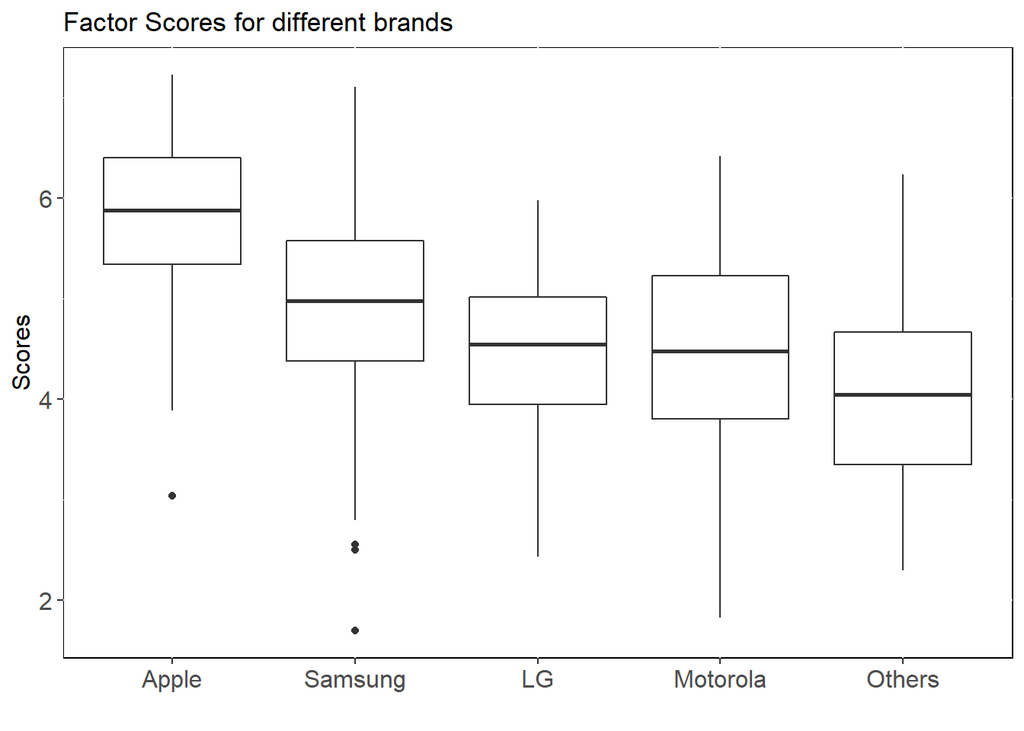

```r
# extract the scores for the different brands from the linear models and create data tables for all of them
appleDT = data.table("Brand" = "Apple",
                     "Scores" = predict(apple, type = "response"))
samsungDT = data.table("Brand" = "Samsung",
                       "Scores" = predict(samsung, type = "response"))
lgDT = data.table("Brand" = "LG",
                  "Scores" = predict(lg, type = "response"))
motorolaDT = data.table("Brand" = "Motorola",
                        "Scores" = predict(motorola, type = "response"))
othersDT = data.table("Brand" = "Others",
                     "Scores" = predict(others, type = "response"))

scores = rbind(appleDT, samsungDT, lgDT, motorolaDT, othersDT) # connect the data tables to a single one
scores$Brand = as.factor(scores$Brand) # convert "Brand" to a factor

# create a ggplot with the boxplots for the scores for the brands side by side
ggplot(scores, aes(x = factor(Brand, level = c("Apple", "Samsung", "LG", "Motorola", "Others")), y = Scores)) + # set the data and the order of the brands
  geom_boxplot() + # create the boxplots
  theme(legend.title = element_blank(), # remove the legend title
          axis.text=element_text(size=12), # change the axis text size
          axis.title=element_text(size=12), # change the axis title size
          panel.background = element_rect(fill = "white", colour = "black"), # change the background colors
          panel.grid.major = element_line(colour = "white", size = 0.5)) + # change the grid appearance3
  labs(title = "Factor Scores for different brands", # set the title
       x = "", # no x-axis title
       y = "Scores") # set the y-axis title
```

It appears that all factor scores are positive, roughly ranging from 2 to 7. Apple as the supposedly strongest brand has also the highest factor score, followed by Samsung, LG, Motorola and others as it would be intuitive with regard to their public appearance and reputation. Maybe this analysis is a bit outdated since neither LG nor Motorola are under the 5 current most important smartphone brands. They have been replaced by mainly Chinese brands like Huawei, Xiaomi and Oppo. (1) Also, Samsung is the No. 1 with respect to shipments and market share while Apple is only on the 2nd rank. (2) This does not directly refer to brand perception or relevant factors for brand perception but needs to be reminded of when looking at the last section of the analysis.

## References

### Webpages

(1): https://www.globalbrandsmagazine.com/top-10-mobile-brands-in-world/, accessed 05.04.2023, 17:36.

(2): https://www.mbaskool.com/fun-corner/top-brand-lists/17610-top-10-global-mobile-phone-brands.html, accessed 05.04.2023, 17:37.

### Packages

Revelle, W. (2022) psych: Procedures for Personality and Psychological Research, Northwestern University, Evanston, Illinois, USA, https://CRAN.R-project.org/package=psych Version = 2.2.9.

Dowle M, Srinivasan A (2021). *data.table: Extension of `data.frame`*. R package version 1.14.2, https://CRAN.R-project.org/package=data.table.

Yihui Xie (2022). knitr: A General-Purpose Package for Dynamic Report Generation in R. R package version 1.40.

Yihui Xie (2015) Dynamic Documents with R and knitr. 2nd edition. Chapman and Hall/CRC. ISBN 978-1498716963

Yihui Xie (2014) knitr: A Comprehensive Tool for Reproducible Research in R. In Victoria Stodden, Friedrich Leisch and Roger D. Peng, editors, Implementing Reproducible Computational Research. Chapman and Hall/CRC. ISBN 978-1466561595

Maier MJ (2022). *Companion Package to the Book ``R: Einführung durch angewandte Statistik’’*. R package version 0.9.4, https://CRAN.R-project.org/package=REdaS.

Taiyun Wei and Viliam Simko (2021). R package ‘corrplot’: Visualization of a Correlation Matrix (Version 0.92). Available from https://github.com/taiyun/corrplot

Mangiafico S (2023). *rcompanion: Functions to Support Extension Education Program Evaluation*. R package version 2.4.21, https://CRAN.R-project.org/package=rcompanion.